# Sequences, Limits & Convergence

**Track:** Limits & Continuity (Topic 1 of 4)  
**Difficulty:** Foundational  
**Project:** formalCalculus — formalcalculus.com  
**Author:** Jonathan Rocha  
**Date:** 2026-03-29

This notebook develops the rigorous theory of sequences and limits in $\mathbb{R}$ — the foundation on which all of calculus rests. We begin with the informal intuition ("getting arbitrarily close"), formalize it with the $\varepsilon$-$N$ definition, and build up to the key convergence theorems that ML practitioners rely on (often without knowing it): the Monotone Convergence Theorem, Bolzano-Weierstrass, and Cauchy's criterion.

**ML motivation:** Every time you watch a training loss curve flatten out, you're watching a sequence converge. The rigorous theory tells you *when* convergence is guaranteed, *how fast* it happens, and *what can go wrong*. Gradient descent convergence proofs, PAC learning bounds, and MCMC mixing times all rest on the theorems developed here.

**Notebook structure:**

1. Setup & imports
2. Sequences: definition, visualization, and examples
3. The $\varepsilon$-$N$ definition of convergence
4. Convergence theorems (Monotone Convergence, Squeeze, Algebra of Limits)
5. Subsequences & Bolzano-Weierstrass
6. Cauchy sequences & completeness
7. Rates of convergence
8. ML connections: gradient descent, MCMC, empirical risk

**Publication-quality figures:** All matplotlib figures use consistent styling for export to `public/images/topics/sequences-limits/`.

## Setup

```python
# Core dependencies
import numpy as np
import matplotlib.pyplot as plt
import matplotlib.patches as mpatches
from matplotlib.collections import LineCollection
from typing import Callable, List, Tuple, Optional
import warnings
warnings.filterwarnings('ignore')

# Publication-quality figure defaults
plt.rcParams.update({
    'figure.figsize': (10, 6),
    'figure.dpi': 150,
    'font.size': 12,
    'font.family': 'serif',
    'axes.titlesize': 14,
    'axes.labelsize': 12,
    'xtick.labelsize': 10,
    'ytick.labelsize': 10,
    'legend.fontsize': 10,
    'lines.linewidth': 1.5,
    'axes.spines.top': False,
    'axes.spines.right': False,
    'figure.facecolor': 'white',
    'axes.facecolor': 'white',
    'savefig.bbox': 'tight',
    'savefig.pad_inches': 0.1,
})

# Color palette — consistent across all formalCalculus notebooks
COLORS = {
    'primary': '#2563EB',       # Blue — main function/sequence
    'secondary': '#DC2626',     # Red — secondary function/limit
    'accent': '#059669',        # Green — convergence/success
    'warning': '#D97706',       # Amber — divergence/caution
    'muted': '#6B7280',         # Gray — axes, annotations
    'epsilon_band': '#BFDBFE',  # Light blue — epsilon neighborhoods
    'highlight': '#7C3AED',     # Purple — highlighted elements
    'bg_region': '#F3F4F6',     # Light gray — background regions
}

print("Setup complete — formalCalculus notebook ready.")
print(f"NumPy {np.__version__}, Matplotlib {plt.matplotlib.__version__}")
```

[output not shown]

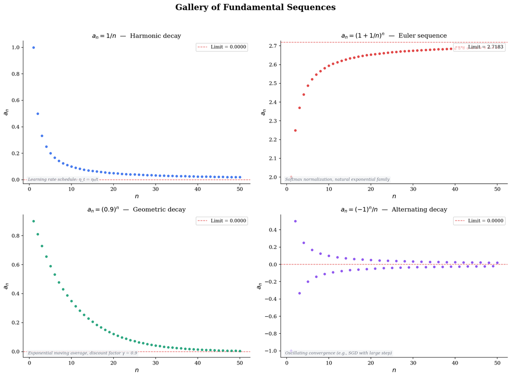

```
→ Saved: sequence-gallery.png
```

```python
# === Section 1: Sequences — Definition, Visualization, and Examples ===
#
# A sequence in R is a function a: N -> R. We write a(n) = a_n and denote the
# sequence by (a_n) or (a_1, a_2, a_3, ...).
#
# Key examples for ML practitioners:
# - a_n = 1/n          (harmonic decay — learning rate schedules)
# - a_n = (1 + 1/n)^n  (approaches e — appears in compound growth, softmax)
# - a_n = r^n           (geometric — exponential decay, discount factors)
# - a_n = (-1)^n / n    (alternating — oscillating convergence)

def sequence_gallery():
    """Visualize a gallery of fundamental sequences with ML context."""

    n = np.arange(1, 51)

    sequences = {
        r'$a_n = 1/n$': {
            'values': 1.0 / n,
            'limit': 0,
            'label': 'Harmonic decay',
            'ml_note': 'Learning rate schedule: η_t = η₀/t',
            'color': COLORS['primary'],
        },
        r'$a_n = (1 + 1/n)^n$': {
            'values': (1 + 1.0/n)**n,
            'limit': np.e,
            'label': 'Euler sequence',
            'ml_note': 'Softmax normalization, natural exponential family',
            'color': COLORS['secondary'],
        },
        r'$a_n = (0.9)^n$': {
            'values': 0.9**n,
            'limit': 0,
            'label': 'Geometric decay',
            'ml_note': 'Exponential moving average, discount factor γ = 0.9',
            'color': COLORS['accent'],
        },
        r'$a_n = (-1)^n / n$': {
            'values': ((-1.0)**n) / n,
            'limit': 0,
            'label': 'Alternating decay',
            'ml_note': 'Oscillating convergence (e.g., SGD with large step)',
            'color': COLORS['highlight'],
        },
    }

    fig, axes = plt.subplots(2, 2, figsize=(14, 10))
    axes = axes.flatten()

    for ax, (title, seq) in zip(axes, sequences.items()):
        ax.scatter(n, seq['values'], s=15, color=seq['color'], zorder=3, alpha=0.8)
        ax.axhline(y=seq['limit'], color=COLORS['secondary'], linestyle='--',
                   linewidth=1, alpha=0.7, label=f"Limit = {seq['limit']:.4f}")
        ax.set_xlabel('$n$')
        ax.set_ylabel('$a_n$')
        ax.set_title(f"{title}  —  {seq['label']}", fontsize=12)
        ax.legend(loc='upper right', fontsize=9)

        # ML context annotation
        ax.annotate(seq['ml_note'], xy=(0.02, 0.02), xycoords='axes fraction',
                   fontsize=8, color=COLORS['muted'], fontstyle='italic',
                   bbox=dict(boxstyle='round,pad=0.3', facecolor=COLORS['bg_region'],
                            edgecolor='none', alpha=0.8))

    fig.suptitle('Gallery of Fundamental Sequences', fontsize=16, fontweight='bold', y=1.02)
    plt.tight_layout()
    plt.savefig('sequence-gallery.png', dpi=150)
    plt.show()
    print("→ Saved: sequence-gallery.png")

sequence_gallery()
```

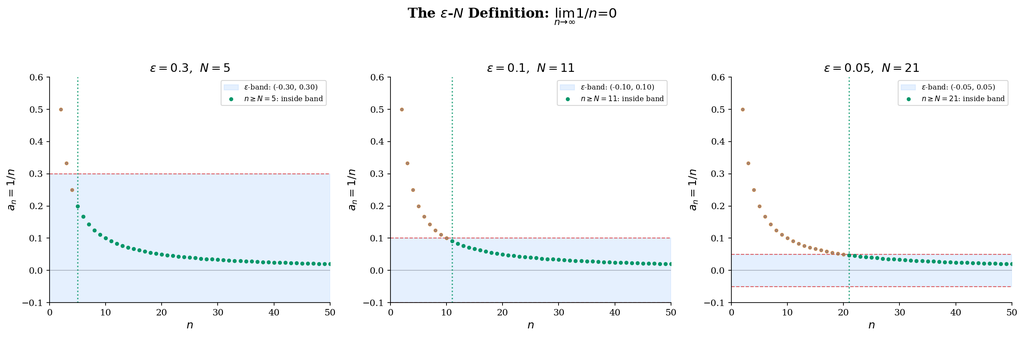

```
→ Saved: epsilon-n-definition.png
```

```python
# === Section 2: The ε-N Definition of Convergence ===
#
# DEFINITION (Convergence of a Sequence):
# A sequence (a_n) converges to L ∈ R if for every ε > 0, there exists N ∈ N
# such that for all n ≥ N, |a_n - L| < ε.
#
# In symbols: lim_{n→∞} a_n = L  ⟺  ∀ε > 0, ∃N ∈ N : n ≥ N ⟹ |a_n - L| < ε
#
# The interactive D3 visualization on the site will let users drag ε and watch N respond.
# This static figure shows the concept for multiple ε values.

def epsilon_N_visualization():
    """Visualize the ε-N definition for a_n = 1/n → 0."""

    n = np.arange(1, 101)
    a_n = 1.0 / n
    L = 0.0

    epsilons = [0.3, 0.1, 0.05]

    fig, axes = plt.subplots(1, 3, figsize=(16, 5))

    for ax, eps in zip(axes, epsilons):
        # The sequence
        ax.scatter(n, a_n, s=8, color=COLORS['primary'], alpha=0.6, zorder=3)

        # Limit line
        ax.axhline(y=L, color=COLORS['muted'], linestyle='-', linewidth=0.8, alpha=0.5)

        # Epsilon band
        ax.axhspan(L - eps, L + eps, color=COLORS['epsilon_band'], alpha=0.4,
                   label=f'$\\varepsilon$-band: ({L-eps:.2f}, {L+eps:.2f})')
        ax.axhline(y=L + eps, color=COLORS['secondary'], linestyle='--', linewidth=1, alpha=0.7)
        ax.axhline(y=L - eps, color=COLORS['secondary'], linestyle='--', linewidth=1, alpha=0.7)

        # Find N: smallest n such that 1/n < ε, i.e., n > 1/ε
        N = int(np.ceil(1.0 / eps)) + 1

        # Vertical line at N
        ax.axvline(x=N, color=COLORS['accent'], linestyle=':', linewidth=1.5, alpha=0.8)

        # Highlight terms inside the band (n ≥ N)
        inside = n >= N
        ax.scatter(n[inside], a_n[inside], s=12, color=COLORS['accent'], zorder=4,
                   label=f'$n \geq N = {N}$: inside band')

        # Highlight terms outside (n < N)
        outside = n < N
        ax.scatter(n[outside], a_n[outside], s=12, color=COLORS['warning'], zorder=4,
                   alpha=0.5)

        ax.set_xlabel('$n$')
        ax.set_ylabel('$a_n = 1/n$')
        ax.set_title(f'$\\varepsilon = {eps}$,  $N = {N}$', fontsize=13)
        ax.set_xlim(0, 50)
        ax.set_ylim(-0.1, 0.6)
        ax.legend(fontsize=8, loc='upper right')

    fig.suptitle(r'The $\varepsilon$-$N$ Definition: $\lim_{n \to \infty} 1/n = 0$',
                 fontsize=15, fontweight='bold', y=1.04)
    plt.tight_layout()
    plt.savefig('epsilon-n-definition.png', dpi=150)
    plt.show()
    print("→ Saved: epsilon-n-definition.png")

epsilon_N_visualization()
```

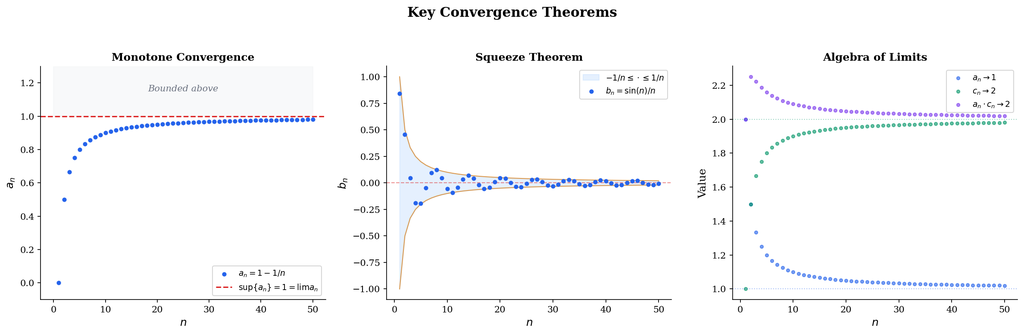

```
→ Saved: convergence-theorems.png
```

```python
# === Section 3: Convergence Theorems ===
#
# THEOREM (Monotone Convergence Theorem):
# Every bounded monotone sequence converges.
# - If (a_n) is increasing and bounded above, then lim a_n = sup{a_n}.
# - If (a_n) is decreasing and bounded below, then lim a_n = inf{a_n}.
#
# THEOREM (Squeeze Theorem):
# If a_n ≤ b_n ≤ c_n for all n ≥ N₀, and lim a_n = lim c_n = L, then lim b_n = L.
#
# THEOREM (Algebra of Limits):
# If lim a_n = A and lim b_n = B, then:
# - lim (a_n + b_n) = A + B
# - lim (a_n · b_n) = A · B
# - lim (a_n / b_n) = A / B  (if B ≠ 0)

def convergence_theorems_figure():
    """Three-panel figure illustrating the key convergence theorems."""

    n = np.arange(1, 51)

    fig, axes = plt.subplots(1, 3, figsize=(16, 5))

    # Panel 1: Monotone Convergence Theorem
    ax = axes[0]
    # a_n = 1 - 1/n (increasing, bounded above by 1)
    a_n = 1 - 1.0/n
    ax.scatter(n, a_n, s=15, color=COLORS['primary'], zorder=3, label=r'$a_n = 1 - 1/n$')
    ax.axhline(y=1.0, color=COLORS['secondary'], linestyle='--', linewidth=1.5,
               label=r'$\sup\{a_n\} = 1 = \lim a_n$')
    ax.fill_between([0, 50], [1, 1], [1.3, 1.3], color=COLORS['bg_region'], alpha=0.5)
    ax.annotate('Bounded above', xy=(25, 1.15), ha='center', fontsize=10,
                color=COLORS['muted'], fontstyle='italic')
    ax.set_xlabel('$n$')
    ax.set_ylabel('$a_n$')
    ax.set_title('Monotone Convergence', fontsize=12, fontweight='bold')
    ax.set_ylim(-0.1, 1.3)
    ax.legend(fontsize=9)

    # Panel 2: Squeeze Theorem
    ax = axes[1]
    # b_n = sin(n)/n, squeezed by -1/n ≤ sin(n)/n ≤ 1/n
    b_n = np.sin(n) / n
    upper = 1.0 / n
    lower = -1.0 / n
    ax.fill_between(n, lower, upper, color=COLORS['epsilon_band'], alpha=0.4,
                    label=r'$-1/n \leq \cdot \leq 1/n$')
    ax.plot(n, upper, color=COLORS['warning'], linewidth=1, alpha=0.7)
    ax.plot(n, lower, color=COLORS['warning'], linewidth=1, alpha=0.7)
    ax.scatter(n, b_n, s=15, color=COLORS['primary'], zorder=3,
               label=r'$b_n = \sin(n)/n$')
    ax.axhline(y=0, color=COLORS['secondary'], linestyle='--', linewidth=1, alpha=0.5)
    ax.set_xlabel('$n$')
    ax.set_ylabel('$b_n$')
    ax.set_title('Squeeze Theorem', fontsize=12, fontweight='bold')
    ax.legend(fontsize=9)

    # Panel 3: Algebra of Limits
    ax = axes[2]
    a_n = 1 + 1.0/n      # → 1
    c_n = 2 - 1.0/n      # → 2
    product = a_n * c_n   # → 2
    ax.scatter(n, a_n, s=12, color=COLORS['primary'], alpha=0.6, label=r'$a_n \to 1$')
    ax.scatter(n, c_n, s=12, color=COLORS['accent'], alpha=0.6, label=r'$c_n \to 2$')
    ax.scatter(n, product, s=12, color=COLORS['highlight'], alpha=0.6,
               label=r'$a_n \cdot c_n \to 2$')
    ax.axhline(y=1, color=COLORS['primary'], linestyle=':', linewidth=1, alpha=0.4)
    ax.axhline(y=2, color=COLORS['accent'], linestyle=':', linewidth=1, alpha=0.4)
    ax.set_xlabel('$n$')
    ax.set_ylabel('Value')
    ax.set_title('Algebra of Limits', fontsize=12, fontweight='bold')
    ax.legend(fontsize=9)

    fig.suptitle('Key Convergence Theorems', fontsize=15, fontweight='bold', y=1.03)
    plt.tight_layout()
    plt.savefig('convergence-theorems.png', dpi=150)
    plt.show()
    print("→ Saved: convergence-theorems.png")

convergence_theorems_figure()
```

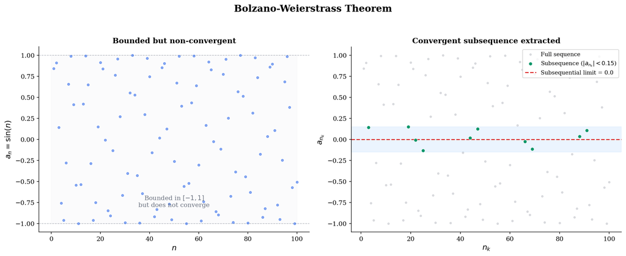

```
→ Saved: bolzano-weierstrass.png
```

```python
# === Section 4: Subsequences & Bolzano-Weierstrass ===
#
# DEFINITION (Subsequence):
# Given a sequence (a_n), a subsequence is (a_{n_k}) where n_1 < n_2 < n_3 < ...
# is a strictly increasing sequence of natural numbers.
#
# THEOREM (Bolzano-Weierstrass):
# Every bounded sequence in R has a convergent subsequence.
#
# This is one of the most important theorems in analysis. It guarantees that bounded
# sequences can't "escape" — they must cluster somewhere. In ML, this underpins
# compactness arguments in optimization (existence of minimizers on compact sets)
# and the convergence of subsequences in stochastic gradient methods.

def bolzano_weierstrass_figure():
    """Visualize Bolzano-Weierstrass: extracting a convergent subsequence."""

    np.random.seed(42)  # Deterministic for reproducibility

    # A bounded but non-convergent sequence: a_n = sin(n) (bounded in [-1, 1])
    n = np.arange(1, 101)
    a_n = np.sin(n)

    fig, axes = plt.subplots(1, 2, figsize=(14, 5.5))

    # Panel 1: Full sequence — bounded, oscillating, no single limit
    ax = axes[0]
    ax.scatter(n, a_n, s=12, color=COLORS['primary'], alpha=0.5, zorder=3)
    ax.axhline(y=1, color=COLORS['muted'], linestyle='--', linewidth=0.8, alpha=0.5)
    ax.axhline(y=-1, color=COLORS['muted'], linestyle='--', linewidth=0.8, alpha=0.5)
    ax.fill_between([0, 100], [-1, -1], [1, 1], color=COLORS['bg_region'], alpha=0.3)
    ax.set_xlabel('$n$')
    ax.set_ylabel('$a_n = \sin(n)$')
    ax.set_title('Bounded but non-convergent', fontsize=12, fontweight='bold')
    ax.annotate('Bounded in $[-1, 1]$\nbut does not converge',
                xy=(50, -0.8), ha='center', fontsize=10, color=COLORS['muted'])

    # Panel 2: Extract a convergent subsequence
    # Use n_k such that sin(n_k) → some value.
    # A natural choice: n_k where sin(n_k) is closest to 0 (converging to 0).
    ax = axes[1]
    ax.scatter(n, a_n, s=8, color=COLORS['muted'], alpha=0.2, zorder=2, label='Full sequence')

    # Find subsequence indices where |a_n| < threshold, progressively tighter
    # This simulates the bisection proof of B-W
    subseq_indices = []
    target = 0.0
    threshold = 0.15
    for i in range(len(n)):
        if abs(a_n[i] - target) < threshold:
            subseq_indices.append(i)

    subseq_n = n[subseq_indices]
    subseq_vals = a_n[subseq_indices]

    ax.scatter(subseq_n, subseq_vals, s=30, color=COLORS['accent'], zorder=4,
               edgecolors='white', linewidth=0.5, label=f'Subsequence ($|a_{{n_k}}| < {threshold}$)')
    ax.axhline(y=target, color=COLORS['secondary'], linestyle='--', linewidth=1.5,
               label=f'Subsequential limit = {target}')
    ax.axhspan(target - threshold, target + threshold, color=COLORS['epsilon_band'],
               alpha=0.3)
    ax.set_xlabel('$n_k$')
    ax.set_ylabel('$a_{n_k}$')
    ax.set_title('Convergent subsequence extracted', fontsize=12, fontweight='bold')
    ax.legend(fontsize=9, loc='upper right')

    fig.suptitle('Bolzano-Weierstrass Theorem', fontsize=15, fontweight='bold', y=1.03)
    plt.tight_layout()
    plt.savefig('bolzano-weierstrass.png', dpi=150)
    plt.show()
    print("→ Saved: bolzano-weierstrass.png")

bolzano_weierstrass_figure()
```

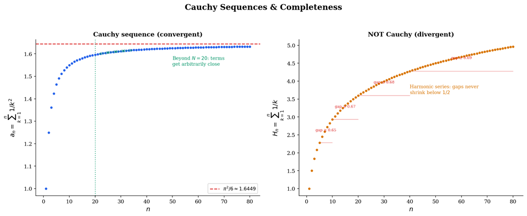

```
→ Saved: cauchy-sequences.png
```

```python
# === Section 5: Cauchy Sequences & Completeness ===
#
# DEFINITION (Cauchy Sequence):
# A sequence (a_n) is Cauchy if for every ε > 0, there exists N ∈ N such that
# for all m, n ≥ N, |a_m - a_n| < ε.
#
# THEOREM (Completeness of R):
# A sequence in R converges if and only if it is Cauchy.
#
# This is the completeness property of R — the reason R is the "right" number system
# for calculus. Q (the rationals) is NOT complete: the sequence of decimal approximations
# to √2 is Cauchy in Q but does not converge in Q.
#
# ML connection: Completeness guarantees that gradient descent sequences in R^n have
# limits (when bounded and Cauchy). Banach's fixed-point theorem — the workhorse of
# contraction mapping proofs — requires completeness.

def cauchy_sequence_figure():
    """Visualize the Cauchy property: terms getting arbitrarily close to each other."""

    n = np.arange(1, 81)

    fig, axes = plt.subplots(1, 2, figsize=(14, 5.5))

    # Panel 1: Cauchy sequence — a_n = sum_{k=1}^{n} 1/k^2 (converges to π²/6)
    ax = axes[0]
    a_n = np.cumsum(1.0 / n**2)
    limit = np.pi**2 / 6

    ax.scatter(n, a_n, s=12, color=COLORS['primary'], zorder=3)
    ax.axhline(y=limit, color=COLORS['secondary'], linestyle='--', linewidth=1.5,
               label=f'$\\pi^2/6 \\approx {limit:.4f}$')

    # Show Cauchy property: highlight pairs of terms close together for large n
    N_demo = 20
    ax.axvline(x=N_demo, color=COLORS['accent'], linestyle=':', linewidth=1.5, alpha=0.7)

    # Show |a_m - a_n| gap shrinking
    for i in range(N_demo, min(N_demo + 10, len(n) - 5), 3):
        j = i + 5
        if j < len(n):
            gap = abs(a_n[j] - a_n[i])
            ax.annotate('', xy=(n[j], a_n[j]), xytext=(n[i], a_n[i]),
                       arrowprops=dict(arrowstyle='<->', color=COLORS['accent'],
                                      linewidth=1, alpha=0.6))

    ax.set_xlabel('$n$')
    ax.set_ylabel(r'$a_n = \sum_{k=1}^{n} 1/k^2$')
    ax.set_title('Cauchy sequence (convergent)', fontsize=12, fontweight='bold')
    ax.legend(fontsize=9)
    ax.annotate(f'Beyond $N={N_demo}$: terms\nget arbitrarily close',
                xy=(50, a_n[20] - 0.05), fontsize=9, color=COLORS['accent'])

    # Panel 2: NOT Cauchy — harmonic series a_n = sum 1/k (diverges)
    ax = axes[1]
    h_n = np.cumsum(1.0 / n)

    ax.scatter(n, h_n, s=12, color=COLORS['warning'], zorder=3)

    # Show that gaps do NOT shrink — |a_{2N} - a_N| ≥ 1/2 always
    markers_N = [5, 10, 20, 40]
    for N_val in markers_N:
        if 2 * N_val - 1 < len(n):
            y1 = h_n[N_val - 1]
            y2 = h_n[2 * N_val - 1]
            gap = y2 - y1
            ax.plot([N_val, 2*N_val], [y1, y1], color=COLORS['secondary'],
                    linewidth=0.8, alpha=0.5)
            ax.annotate(f'gap ≥ {gap:.2f}', xy=(1.5 * N_val, (y1 + y2)/2),
                       fontsize=7, color=COLORS['secondary'], ha='center')

    ax.set_xlabel('$n$')
    ax.set_ylabel(r'$H_n = \sum_{k=1}^{n} 1/k$')
    ax.set_title('NOT Cauchy (divergent)', fontsize=12, fontweight='bold')
    ax.annotate('Harmonic series: gaps never\nshrink below $1/2$',
                xy=(40, h_n[20]), fontsize=9, color=COLORS['warning'])

    fig.suptitle('Cauchy Sequences & Completeness', fontsize=15, fontweight='bold', y=1.03)
    plt.tight_layout()
    plt.savefig('cauchy-sequences.png', dpi=150)
    plt.show()
    print("→ Saved: cauchy-sequences.png")

cauchy_sequence_figure()
```

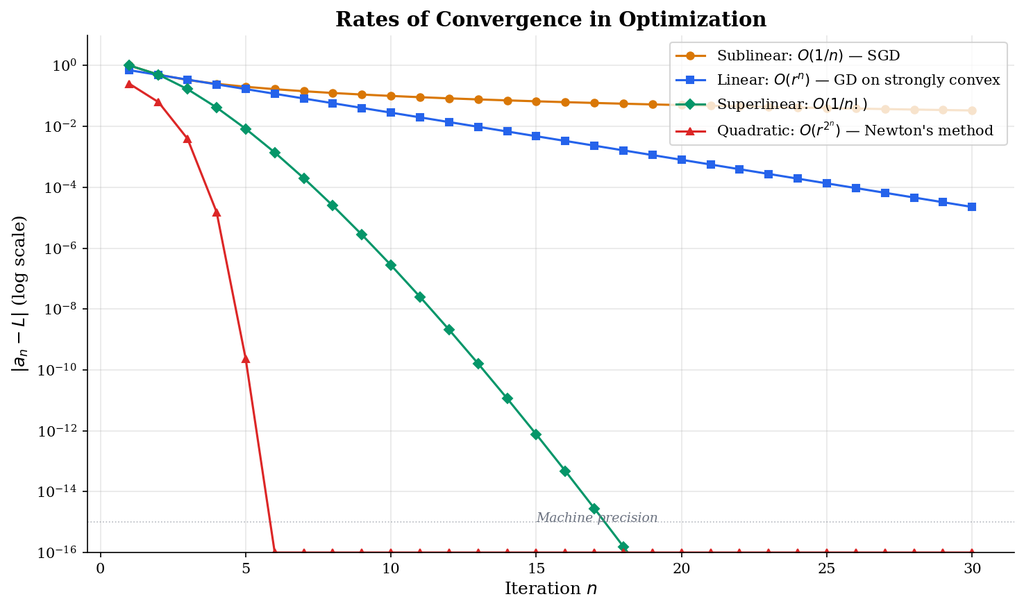

```
→ Saved: convergence-rates.png
```

```python
# === Section 6: Rates of Convergence ===
#
# Not all convergent sequences converge at the same speed. The RATE of convergence
# characterizes how quickly |a_n - L| shrinks, and is critical in ML for understanding
# algorithm efficiency.
#
# DEFINITION (Rate of convergence):
# - Linear (or geometric): |a_{n+1} - L| ≤ r|a_n - L| for some 0 < r < 1
# - Superlinear: |a_{n+1} - L| / |a_n - L| → 0
# - Quadratic: |a_{n+1} - L| ≤ C|a_n - L|^2
# - Sublinear: |a_n - L| = O(1/n^p) for some p > 0
#
# ML connection:
# - Gradient descent on strongly convex functions: LINEAR convergence
# - Newton's method near a solution: QUADRATIC convergence
# - Vanilla SGD: SUBLINEAR convergence O(1/√n)
# - Adam/AdaGrad: between sublinear and linear depending on conditions

def convergence_rates_figure():
    """Compare convergence rates on a log scale."""

    n = np.arange(1, 31)

    # Sublinear: |a_n - L| = 1/n
    sublinear = 1.0 / n

    # Linear: |a_n - L| = 0.7^n
    linear = 0.7**n

    # Superlinear: |a_n - L| = 1/n!  (approximate via gamma)
    from math import factorial
    superlinear = np.array([1.0 / factorial(k) for k in n])

    # Quadratic: |a_n - L| = 0.5^(2^n)  (double exponential)
    # Cap at machine epsilon
    quadratic = np.array([0.5**(2**k) if 2**k < 1000 else 1e-300 for k in n])
    quadratic = np.maximum(quadratic, 1e-16)

    fig, ax = plt.subplots(figsize=(10, 6))

    ax.semilogy(n, sublinear, 'o-', color=COLORS['warning'], markersize=5,
                label=r'Sublinear: $O(1/n)$ — SGD')
    ax.semilogy(n, linear, 's-', color=COLORS['primary'], markersize=5,
                label=r'Linear: $O(r^n)$ — GD on strongly convex')
    ax.semilogy(n, superlinear, 'D-', color=COLORS['accent'], markersize=5,
                label=r'Superlinear: $O(1/n!)$')
    ax.semilogy(n, quadratic, '^-', color=COLORS['secondary'], markersize=5,
                label=r"Quadratic: $O(r^{2^n})$ — Newton's method")

    ax.set_xlabel('Iteration $n$', fontsize=12)
    ax.set_ylabel('$|a_n - L|$ (log scale)', fontsize=12)
    ax.set_title('Rates of Convergence in Optimization', fontsize=14, fontweight='bold')
    ax.legend(fontsize=10, loc='upper right')
    ax.set_ylim(1e-16, 10)
    ax.grid(True, alpha=0.3, which='both')

    # Annotate ML context
    ax.annotate('Machine precision', xy=(15, 1e-15), fontsize=9, color=COLORS['muted'],
                fontstyle='italic')
    ax.axhline(y=1e-15, color=COLORS['muted'], linestyle=':', linewidth=0.8, alpha=0.5)

    plt.tight_layout()
    plt.savefig('convergence-rates.png', dpi=150)
    plt.show()
    print("→ Saved: convergence-rates.png")

convergence_rates_figure()
```

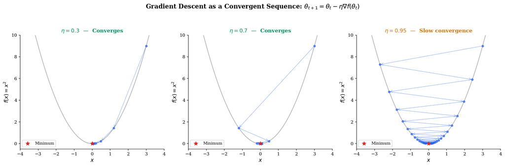

```
→ Saved: gd-as-sequence.png
```

```python
# === Section 7: ML Connections ===
#
# This section makes explicit the bridges between sequence convergence theory
# and machine learning. Each connection points forward to a formalml.com topic.
#
# 1. GRADIENT DESCENT AS A SEQUENCE
#    θ_{t+1} = θ_t - η∇f(θ_t) defines a sequence (θ_t) in R^d.
#    Convergence theorems tell us when and how fast this sequence converges.
#    → formalml.com/topics/gradient-descent
#
# 2. EMPIRICAL RISK CONVERGENCE
#    R̂_n(h) = (1/n) Σ L(h(x_i), y_i) → R(h) = E[L(h(X), Y)] as n → ∞
#    This is a sequence of random variables converging (law of large numbers).
#    → formalml.com/topics/pac-learning
#
# 3. MCMC MIXING
#    Markov chain samples x_1, x_2, ... converge in distribution to the target.
#    Mixing time = how many steps until the chain is "close enough."
#    → formalml.com/topics/random-walks
#
# 4. LEARNING RATE SCHEDULES
#    η_t = η_0 / t^α defines a sequence. Convergence of SGD requires
#    Σ η_t = ∞ (steps are big enough to explore) and Σ η_t² < ∞ (steps shrink fast enough).
#    The Robbins-Monro conditions are statements about series convergence.

def gradient_descent_as_sequence():
    """Visualize gradient descent on f(x) = x² as a convergent sequence."""

    f = lambda x: x**2
    grad_f = lambda x: 2*x

    # Run GD with different learning rates
    learning_rates = [0.3, 0.7, 0.95]
    x0 = 3.0
    n_steps = 30

    fig, axes = plt.subplots(1, 3, figsize=(16, 5))

    for ax, eta in zip(axes, learning_rates):
        # Generate the sequence
        x = [x0]
        for _ in range(n_steps):
            x_new = x[-1] - eta * grad_f(x[-1])
            x.append(x_new)
        x = np.array(x)

        # Plot x as function
        x_plot = np.linspace(-3.5, 3.5, 200)
        ax.plot(x_plot, f(x_plot), color=COLORS['muted'], linewidth=1.5, alpha=0.5)

        # Plot the GD path
        for i in range(len(x) - 1):
            ax.annotate('', xy=(x[i+1], f(x[i+1])), xytext=(x[i], f(x[i])),
                       arrowprops=dict(arrowstyle='->', color=COLORS['primary'],
                                      linewidth=0.8, alpha=0.5))

        ax.scatter(x, f(x), s=20, color=COLORS['primary'], zorder=3, alpha=0.7)
        ax.scatter([0], [0], s=80, color=COLORS['secondary'], marker='*', zorder=5,
                   label='Minimum')

        # Determine convergence behavior
        if abs(x[-1]) < 0.01:
            behavior = 'Converges'
            color = COLORS['accent']
        elif abs(x[-1]) > abs(x[0]):
            behavior = 'Diverges'
            color = COLORS['secondary']
        else:
            behavior = 'Slow convergence'
            color = COLORS['warning']

        ax.set_xlabel('$x$')
        ax.set_ylabel('$f(x) = x^2$')
        ax.set_title(f'$\eta = {eta}$  —  {behavior}', fontsize=12,
                     fontweight='bold', color=color)
        ax.set_xlim(-4, 4)
        ax.set_ylim(-0.5, 10)
        ax.legend(fontsize=9)

    fig.suptitle('Gradient Descent as a Convergent Sequence: $\\theta_{t+1} = \\theta_t - \eta \\nabla f(\\theta_t)$',
                 fontsize=14, fontweight='bold', y=1.04)
    plt.tight_layout()
    plt.savefig('gd-as-sequence.png', dpi=150)
    plt.show()
    print("→ Saved: gd-as-sequence.png")

gradient_descent_as_sequence()
```